# Homework 2

Author

Sharon Hartzell

Published

June 1, 2026

## Before your start the assignment

- Update the header - put your name in the `author` argument and put today’s date in the `date` argument.
- Click the “Render” button in RStudio and then open the rendered `2-hw2.html` page.
- Then go back and try changing the `theme` argument in the header to something else - you can see other available themes [here](https://quarto.org/docs/output-formats/html-themes.html). Notice the difference when you render now!

## Overview of HW2

Create a data visualization that helps answer the question:

> **How have the number and cost of billion-dollar disasters in the US changed over time?**

You will use the NOAA Billion-Dollar Disaster dataset to explore how visual encoding choices (e.g., color, position, length) help communicate trends clearly and effectively.

**Skills practiced**:

- Downloading and importing real-world data from a public source (NOAA)
- Wrangle and explore a real-world dataset using tidyverse
- Identify appropriate visual encodings based on variable types and goals
- Create a clear and effective time-series visualization with ggplot2
- Apply design principles (titles, colors, themes, alt text) for accessibility and clarity

### Load Required Packages

```r
library(tidyverse) #Allows me to use an interconnected set of packages including ggplot2 to create sophisticated visualizations, and dplyr to allow manipulation of data
library(janitor) #Enables cleaning of dirty datasets
library(gghighlight) #Enables me to select specific geometric objects in my visualizations
# load other packages as you see fit but remember to add comments to explain what each package does
```

## Q1: Prepare the data

Following these steps to download and read in the dataset:

1. Download the dataset from [NOAA](https://www.ncei.noaa.gov/access/metadata/landing-page/bin/iso?id=gov.noaa.nodc:0209268). Under “Access” tab, choose the HTTPS option to download the data. Scroll to the bottom of the list to download the **most recent published version**. Read more about the dataset [here](https://www.ncei.noaa.gov/access/billions/).
2. Place the downloaded CSV file `events-US-1980-2024-Q4.csv` into your `data/` folder in your HW repository. You will notice there is a graph that comes with the data, we will circle back to it later.
3. Add your data/ folder to .gitignore to avoid pushing data to GitHub.

# in the terminal, I entered the following to add data folder to .gitignore

touch .gitignore echo “data/” >> .gitignore

4. Read in the CSV file using `read_csv()`

```r
# remove the eval=FALSE when you render quarto document
df_disasters <- read_csv("data/events-US-1980-2024-Q4.csv", skip = 2) |> #Reading in the CSV file to a data frame
  janitor::clean_names() #Function within janitor package used to return a data frame with clean names (case, placement of numbers, replacement of Greek symbols to ASCII, etc.)
# the skip argument is used to skip the first two rows of the CSV file, which contain metadata about the dataset.

head(df_disasters) #familiarizing myelf with the titles of variables in the data frame
```

```
#> # A tibble: 6 × 7
#>   name     disaster begin_date end_date cpi_adjusted_cost unadjusted_cost deaths
#>   <chr>    <chr>         <dbl>    <dbl>             <dbl>           <dbl>  <dbl>
#> 1 Souther… Flooding   19800410 19800417             2749.            707.      7
#> 2 Hurrica… Tropica…   19800807 19800811             2236.            590      13
#> 3 Central… Drought    19800601 19801130            40681.          10020    1260
#> 4 Florida… Freeze     19810112 19810114             2076.            572       0
#> 5 Severe … Severe …   19810505 19810510             1409.            401.     20
#> 6 Midwest… Winter …   19820108 19820116             2218.            662      85
```

5. Skim through the dataset to get familiar with the variable names, especially:
- `disaster`: the type of disaster (e.g., flood, drought, etc.)
- `begin_date`: the date when the disaster began
- `end_date`: the date when the disaster ended
- `cpi_adjusted_cost`: the total damages caused by the disaster (in billions of dollars)
- `deaths`: the number of deaths caused by the disaster
6. Create a new column `year` that extracts the year from the `begin_date` column. You can use the `lubridate` package to do this.

```r
# remove the eval=FALSE when you render quarto document
df_disasters <- df_disasters |>
  mutate(year = lubridate::year(ymd(begin_date)))

head(df_disasters) #checking that year column was added correctly
```

```
#> # A tibble: 6 × 8
#>   name     disaster begin_date end_date cpi_adjusted_cost unadjusted_cost deaths
#>   <chr>    <chr>         <dbl>    <dbl>             <dbl>           <dbl>  <dbl>
#> 1 Souther… Flooding   19800410 19800417             2749.            707.      7
#> 2 Hurrica… Tropica…   19800807 19800811             2236.            590      13
#> 3 Central… Drought    19800601 19801130            40681.          10020    1260
#> 4 Florida… Freeze     19810112 19810114             2076.            572       0
#> 5 Severe … Severe …   19810505 19810510             1409.            401.     20
#> 6 Midwest… Winter …   19820108 19820116             2218.            662      85
#> # ℹ 1 more variable: year <dbl>
```

7. Explore the dataset and answer these questions:
- Are there any missing or zero values in the cost or deaths columns? How might they affect your visualizations?
- What are the top 5 most common disaster types?
- Calculate the total CPI-adjusted cost of disasters per year. Identify the top 3 most expensive years.

```r
#your code here: Exploring the data set:

# Are there any missing or sero values?
df_disasters %>%
  filter(deaths == 0) #filtering by deaths = 0, we see that 101 disasters have 0 deaths
```

```
#> # A tibble: 101 × 8
#>    name    disaster begin_date end_date cpi_adjusted_cost unadjusted_cost deaths
#>    <chr>   <chr>         <dbl>    <dbl>             <dbl>           <dbl>  <dbl>
#>  1 Florid… Freeze     19810112 19810114             2076.            572       0
#>  2 Southe… Drought    19830601 19830831             9574            2964.      0
#>  3 Florid… Freeze     19850120 19850122             3588            1200       0
#>  4 Northe… Drought    19890601 19891130             7838.           3003.      0
#>  5 Colora… Severe …   19900711 19900711             1984.            820.      0
#>  6 Califo… Freeze     19901218 19901225             8432            3400       0
#>  7 Severe… Severe …   19910326 19910329             1509.            645       0
#>  8 U.S. D… Drought    19910301 19910831             7040.           3008.      0
#>  9 Severe… Severe …   19920324 19920325             1818.            804.      0
#> 10 Hail, … Severe …   19920428 19920429             2157             954.      0
#> # ℹ 91 more rows
#> # ℹ 1 more variable: year <dbl>
```

```r
df_disasters %>%
  filter(cpi_adjusted_cost == 0) #filtering by cpi adjusted cost = 0, we see that no disasters have 0 values
```

```
#> # A tibble: 0 × 8
#> # ℹ 8 variables: name <chr>, disaster <chr>, begin_date <dbl>, end_date <dbl>,
#> #   cpi_adjusted_cost <dbl>, unadjusted_cost <dbl>, deaths <dbl>, year <dbl>
```

```r
df_disasters %>%
  filter(unadjusted_cost == 0) #filtering by unadjusted cost, we also have no disasters with 0 values
```

```
#> # A tibble: 0 × 8
#> # ℹ 8 variables: name <chr>, disaster <chr>, begin_date <dbl>, end_date <dbl>,
#> #   cpi_adjusted_cost <dbl>, unadjusted_cost <dbl>, deaths <dbl>, year <dbl>
```

```r
anyNA(df_disasters) #Ran this function to see if any values are missing
```

```
#> [1] FALSE
```

```r
# What are the five most common disaster types?
df_disasters %>%
  count(disaster) %>% #Using count function to generate a count for each disaster type, to see what the most common disaster types are
  arrange(desc(n)) # arranging in descending order of count
```

```
#> # A tibble: 7 × 2
#>   disaster             n
#>   <chr>            <int>
#> 1 Severe Storm       203
#> 2 Tropical Cyclone    67
#> 3 Flooding            45
#> 4 Drought             32
#> 5 Winter Storm        24
#> 6 Wildfire            23
#> 7 Freeze               9
```

```r
# Most expensive years

df_disasters %>%
  group_by(year) %>% #Grouping by the newly created year column
  summarise(total_cpi_adj_cost = sum(cpi_adjusted_cost)) %>% #creating a summary table that calculates the sum of cpi adjusted cost for each year
  arrange(desc(total_cpi_adj_cost)) #arranging in descending order to easily see most expensive years
```

```
#> # A tibble: 44 × 2
#>     year total_cpi_adj_cost
#>    <dbl>              <dbl>
#>  1  2017            395936.
#>  2  2005            268593.
#>  3  2022            188353.
#>  4  2024            182714.
#>  5  2021            164299.
#>  6  2012            158736.
#>  7  2020            120585.
#>  8  2018            116034.
#>  9  2011             97936.
#> 10  2008             93956.
#> # ℹ 34 more rows
```

**NoteYour Answer**

- Missing data: There are no missing data values, but we have 101 storm events where the number of deaths was 0. This should not create too many problems for my visualizations, though I know I will not be able to truncate any axes that represent deaths.
- 5 most disaster types: Severe Storm (n = 203), Tropical Cyclone (n = 67), Flooding (n = 45), Drought (n = 32), and Winter Storm (n = 24)
- 3 most expensive years by CPI-adjusted cost: The three most expensive years were 2017, 2005, and 2022

## Q2: Build your visualization

Create a data visualization that summarizes trends over time (year or decade) in the frequency and/or cost of disasters.

Your final visualization should:

- Use data from 1980 to 2024 only
- Include a title (short, descriptive), subtitle (main takeaway), caption (e.g., “Data: NOAA Billion-Dollar Disasters (accessed 2025)”)
- Apply strategies for highlighting patterns or trends (e.g., highlighting recent years, distinguishing types of disasters)
- Use custom colors rather than ggplot defaults
- Use a clean, polished theme
- Include at least one theme adjustments (e.g., axis labels, legend position, font size) to improve readability/visual appeal

```r
#your code here: Comparing trends in natural disaster frequency and cost by decade

df_disasters_decade <-df_disasters %>% # with this block of code, I am creating a new column breaking the dataset into decades in case I want to group or facet by decade, or call out specific decades by highlighting
  mutate(decade = case_when(
    year <= 1980 | year <= 1989 ~ "1980s",
    year <= 1990 | year <= 1999 ~ "1990s",
    year <= 2000 | year <= 2009 ~ "2000s",
    year <= 2010 | year <= 2019 ~ "2010s",
    year <= 2020 | year <= 2024 ~ "2020s"
  ))

head(df_disasters) #checking that the column was created correctly
```

```
#> # A tibble: 6 × 8
#>   name     disaster begin_date end_date cpi_adjusted_cost unadjusted_cost deaths
#>   <chr>    <chr>         <dbl>    <dbl>             <dbl>           <dbl>  <dbl>
#> 1 Souther… Flooding   19800410 19800417             2749.            707.      7
#> 2 Hurrica… Tropica…   19800807 19800811             2236.            590      13
#> 3 Central… Drought    19800601 19801130            40681.          10020    1260
#> 4 Florida… Freeze     19810112 19810114             2076.            572       0
#> 5 Severe … Severe …   19810505 19810510             1409.            401.     20
#> 6 Midwest… Winter …   19820108 19820116             2218.            662      85
#> # ℹ 1 more variable: year <dbl>
```

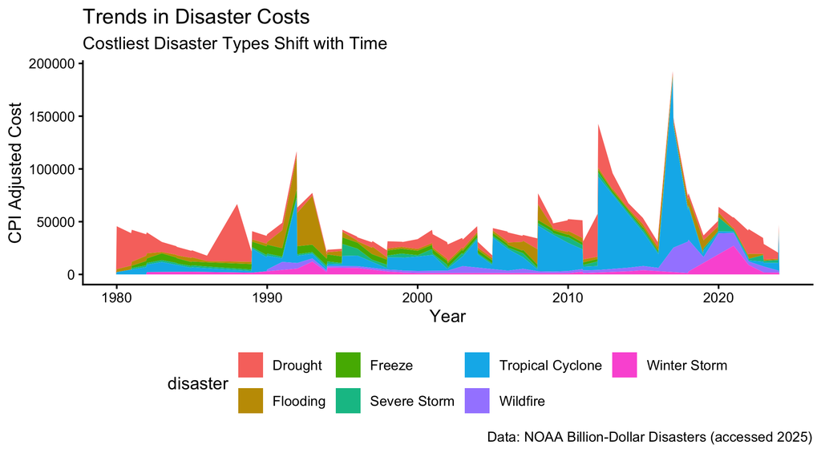

```r
df_disasters_decade %>%
  ggplot(aes(x = year, y = cpi_adjusted_cost, group = disaster, fill = disaster)) + #setting the x axis to year, y to cpi adjusted cost, group to disaster
  geom_area() + #setting chart type as area
  labs(title = "Trends in Disaster Costs", subtitle = "Costliest Disaster Types Shift with Time", x = "Year", y = "CPI Adjusted Cost", caption = "Data: NOAA Billion-Dollar Disasters (accessed 2025)") + #changing labels, captions, title, and subtitle
  theme_classic() + #setting theme as classic
  theme(legend.position = "bottom") #changing legend position
```

What do you notice about the trends over time in the frequency and/or cost of disasters? Anything unexpected?

**NoteYour Answer**

The cost of disaster has not uniformly increased over time, though costs have reached higher peaks since 2010. The most intriguing trend was the shifts over time in the types of disasters that are most costly. While drought was more costly in the 1980s, it now seems to comprise a smaller portion of total disaster costs, with tropical cyclones making up a larger proprtion of the costs. Both wildfires and winter storms have increased greatly over the last ten years. Overall, some oscillation from year to year is observable, perhaps reflecting global climate patterns (El Niño, La Niña, etc.)

## Q3: Reflection

1. What are your variables of interest and what kinds of data (e.g., numeric, categorical, ordered, etc.) are they?

**NoteYour Answer**

My variables of interest are year (numeric, ordered), adjusted cost of disaster (numeric), and disaster type (categorical)

2. How did you decide which type of graphic form was best suited for answering the question? What alternative graphic forms could you have used instead? Why did you settle on this particular form?

**NoteYour Answer**

I tried a few different types of graphics for this chart. Mostly, I was choosing between line graphs and area graphs, and tried both, because they are both well suited to showing trends over time. Ultimately, the line graph was less clear in portraying the comparative costs of different disaster types across years, so although area graphs have compromises in terms of data to ink ratios, I landed on an area chart.

3. What modifications did you make to this viz to improve readability and accessibility?

**NoteYour Answer**

I shifted the disaster type legend to be below the graph, which gave my chart more horizontal room to show temporal trends. I also broke my data down by disaster type in different colors to show the relative contribution of each type of disaster to overall costs. Lastly, I added descriptive labels, titles, and captions to improve readability, and changed the theme to a simple classic style.

4. Is there anything you wanted to implement but didn’t know how? If so, describe it.

**NoteYour Answer**

I was attempting to break my data down into facets by decade, so that I could show decadal trends. While I successfully created a new decade column, and successfully implemented a free x axis so that differences between the decades could be observed, I was not able to change my final decade (2020s) to show all the years with missing data as blank, so I ultimately abandoned this idea. I wanted to see finer-scale trends from year to year but the ultimate layout was confusing, and I would have been in an undesirable position of having to free my y axis to actually see the trends.

## Q4: Critique the original graph from NOAA

[figure not shown]

NOAA Billion-Dollar Disaster Events (1980–2024)

This plot appears on NOAA’s official Billion-Dollar Disaster website and summarizes annual disaster frequency and cost.

1. Describe the graphic
- What type(s) of chart(s) are used?
- What variables are encoded? How are they mapped to visual channels (e.g., position, color, size)?
- What is the intended takeaway?

**NoteYour Answer**

The original NOAA graphic is a mix of a line chart and a stacked bar chart. The line elements of the graph encode combined disaster cost (along with 95% confidence intervals) and separately, 5-year average costs, while the stacked bar charts encode counts of different types of disaster events, demarcated by color. The intended takeaway is that disaster costs have spiked and decreased over time in alternating patterns, with the 5-year average costs generally increasing, as well as the fact that severe storms have grown more numberous over time.

2. Assess strengths
- What aspects of the chart help communicate the intended message clearly?
- Is there anything done particularly well in terms of accessibility, color use, or labeling?

**NoteYour Answer**

The line chart aspects are most successful in communicating the message of the data, in my opinion. They show several different ways of measuring cost over time. I also think the height of the bars is illustrative, showing that overall counts of disasters have increased over time.

3. Assess limitations
- What elements of the chart are **confusing, cluttered, or potentially misleading**?
- Are any visual encodings hard to interpret?
- Does the chart overcomplicate the message or try to show too much?

**NoteYour Answer**

The chart is visually cluttered overall, largely stemming from the use of two overlapping chart types in one graph. The two y axes are also confusing because they are on such different scales. When I first looked at the chart, I was under the impression it was meant to communicate share of costs contributed by each disaster type, not just the counts of disasters themselves. When I visualized this in my own graph, I saw quite different trends - for example, tropical cyclones are not increasing in frequency as much as severe storms, but they are according to my graph becoming more and more costly over time. Additionally, the stacked bar chart makes it difficult to assess trends across disaster type.

4. Recommend improvements
- Suggest **2–3 specific changes** that would improve the effectiveness of the chart.
- Would you consider separating out the lines from the stacked bars? Using interactivity? Changing the layout?

**NoteYour Answer**

1. If I were to include both bar chart and line chart, I would use a neutral bar chart showing only a total count of disasters, rather than breaking it down by type. This would show that as disasters increased, costs have also increased, but it would not be as cluttered or hard to read, and the colors would not detract from the financial trends.
2. I would create a separate plot to show how disaster counts have changed, but rather than using a stacked bar chart I would change it to a parallel coordinate plot.

## BONUS: Create an alternative data visualization from the dataset

- Use the from Data to Viz tool [here](https://www.data-to-viz.com/) to help determine graph types you can use that are different from what you have implemented above
- Create a new visualization that uses a different type of graph than the one you created in Q2.

```r
#your code here
```

**NoteYour Reflection**

## How I used GenAI?

Describe how GenAI is used in producing this homework, include prompt, date, model version, and link to chat history.

**NoteYour Answer**

1. I used Claude.ai version 4.6 (online version) to figure out how to add the data folder to my .gitignore file on June 1, 2026.

Initial Prompt: How do I add a data folder to gitignore? + followup clarifications found at https://claude.ai/share/425015c4-7229-41c2-8f3e-a5ea95db985b

2. I used Claude.ai version 4.6 (online version) on June 1 to figure out how to check for missing values without removing them.

Prompt: How can i inspect a dataframe for missing values in R without removing them? https://claude.ai/share/30aa2a60-9d48-4eab-83a7-b153499132a7

3. In my unsuccessful efforts to create decade facets, I had a conversation with Claude.ai version 4.6 (online version) on June 1 to figure out how to change my axes.

prompt: I’m making a faceted area chart and want to break it down into facets by decade. I have done this successfully, but how do i get each facet to show a different ten years, eg. not have the x axes be fixed?

https://claude.ai/share/a4461bf0-e543-4182-bfdd-6361a38749e2

4. I used Claude.ai version 4.6 online version on June 1 to debug my code and found out I needed to rename my dataframe to include a new column I created

Prompt: help me debug in df_disasters %>% mutate(decade = case_when(year <= 1980 | year <= : could not find function “%>%”

Prompt: need to rename my table after mutating to add new column

https://claude.ai/share/6520b7a1-8441-4f9c-8c63-99b703d0860e

## Save and Push Your Work

Remember to save your `.qmd` and render the HTML output before committing to GitHub.

```bash
git add 2-hw2.qmd 2-hw2.html
git commit -m "Complete Homework 2"
git push
```